# Bankruptcy project in R

Clean workspace

```r
rm(list=ls(all=TRUE))
setwd("C:\\Users\\samanoh\\training\\besantr\\bankruptcy-project")
```

Get Data and view summary

```r
data = read.csv("Bankruptcy_data.csv", header = TRUE)
str(data)
```

```
## 'data.frame':    36553 obs. of  66 variables:
##  $ ID    : int  1 2 3 4 5 6 7 8 9 10 ...
##  $ Attr1 : num  0.13537 0.00586 0.1106 0.06391 0.13168 ...
##  $ Attr2 : num  0.452 0.399 0.161 1.407 0.66 ...
##  $ Attr3 : num  0.312 0.198 0.479 -0.296 0.441 ...
##  $ Attr4 : num  2.047 1.939 7.571 0.529 2.71 ...
##  $ Attr5 : num  10.23 9.58 263.9 -46.29 -23.6 ...
##  $ Attr6 : num  0.168 0 0 -0.714 -0.2 ...
##  $ Attr7 : num  0.16763 0.00724 0.13836 0.07907 0.13191 ...
##  $ Attr8 : num  1.213 1.509 5.205 -0.331 0.514 ...
##  $ Attr9 : num  2.255 0.979 0.684 0.985 2.136 ...
##  $ Attr10: num  0.548 0.601 0.839 -0.465 0.34 ...
##  $ Attr11: num  0.1833 0.0295 0.1388 0.0791 0.1861 ...
##  $ Attr12: num  0.5632 0.0344 1.8983 0.1258 0.5112 ...
##  $ Attr13: num  0.0892 0.0364 0.2362 0.0303 0.1671 ...
```

[output cut: 52 more lines]

COnvert target variable to categorical

```r
data$target = as.factor(as.character(data$target))
data$ID = NULL
str(data)
```

```
## 'data.frame':    36553 obs. of  65 variables:
##  $ Attr1 : num  0.13537 0.00586 0.1106 0.06391 0.13168 ...
##  $ Attr2 : num  0.452 0.399 0.161 1.407 0.66 ...
##  $ Attr3 : num  0.312 0.198 0.479 -0.296 0.441 ...
##  $ Attr4 : num  2.047 1.939 7.571 0.529 2.71 ...
##  $ Attr5 : num  10.23 9.58 263.9 -46.29 -23.6 ...
##  $ Attr6 : num  0.168 0 0 -0.714 -0.2 ...
##  $ Attr7 : num  0.16763 0.00724 0.13836 0.07907 0.13191 ...
##  $ Attr8 : num  1.213 1.509 5.205 -0.331 0.514 ...
##  $ Attr9 : num  2.255 0.979 0.684 0.985 2.136 ...
##  $ Attr10: num  0.548 0.601 0.839 -0.465 0.34 ...
##  $ Attr11: num  0.1833 0.0295 0.1388 0.0791 0.1861 ...
##  $ Attr12: num  0.5632 0.0344 1.8983 0.1258 0.5112 ...
##  $ Attr13: num  0.0892 0.0364 0.2362 0.0303 0.1671 ...
##  $ Attr14: num  0.16763 0.00724 0.13836 0.07907 0.13191 ...
```

[output cut: 51 more lines]

# Perform Random forest to find important attributes

Check for missing values

```r
sum(is.na(data))
```

```
## [1] 35187
```

Perform Central imputation if missing values found

```r
library(DMwR)
ci_data = centralImputation(data = data)
sum(is.na(ci_data))
```

```
## [1] 0
```

Random forest

```r
library(caret)
library(randomForest)
model = randomForest(target ~ ., data=ci_data, keep.forest=TRUE, do.trace=TRUE, ntrees=50)
```

```
## ntree      OOB      1      2
##     1:   6.88%  3.82% 64.36%
##     2:   6.46%  3.66% 60.17%
##     3:   6.57%  3.70% 62.84%
##     4:   6.23%  3.43% 61.73%
##     5:   6.15%  3.16% 64.72%
##     6:   5.92%  2.91% 64.95%
##     7:   5.65%  2.60% 65.60%
##     8:   5.38%  2.22% 67.46%
##     9:   5.13%  1.98% 67.18%
##    10:   4.93%  1.82% 66.13%
##    11:   4.74%  1.61% 66.44%
##    12:   4.64%  1.45% 67.54%
##    13:   4.60%  1.38% 68.12%
##    14:   4.47%  1.22% 68.50%
```

[output cut: 486 more lines]

Find importance from the model

```r
model$importance
```

```
##        MeanDecreaseGini
## Attr1          34.36885
## Attr2          33.47507
## Attr3          42.80645
## Attr4          41.06867
## Attr5          61.02161
## Attr6          62.59128
## Attr7          36.17661
## Attr8          34.06297
## Attr9          74.11032
## Attr10         34.77449
## Attr11         41.56208
## Attr12         36.23386
## Attr13         50.36424
## Attr14         34.17547
## Attr15         45.35363
## Attr16         44.94627
## Attr17         33.42590
## Attr18         34.94623
## Attr19         37.43253
## Attr20         46.87164
## Attr21         39.91131
## Attr22         52.56164
## Attr23         36.63946
## Attr24         93.54611
## Attr25         47.71451
## Attr26         53.03496
## Attr27        222.34324
## Attr28         37.48184
## Attr29         68.81973
## Attr30         39.64575
## Attr31         41.17773
## Attr32         36.58644
## Attr33         42.05744
## Attr34        149.25535
## Attr35         67.69919
## Attr36         51.67503
## Attr37         34.21979
## Attr38         43.52940
## Attr39         68.09890
```

[output cut: 10 more lines]

```
## Attr50         38.46374
## Attr51         37.79476
## Attr52         37.66767
## Attr53         34.59082
## Attr54         39.56354
## Attr55         59.23896
## Attr56         89.75717
## Attr57         38.28186
## Attr58        105.97496
## Attr59         26.93334
## Attr60         47.78155
## Attr61         57.65371
## Attr62         34.34476
## Attr63         35.83373
## Attr64         37.84907
```

Extract important attributes in data frame

```r
rf_imp_attr = data.frame(model$importance)
rf_imp_attr = data.frame(row.names(rf_imp_attr), rf_imp_attr[,1])
colnames(rf_imp_attr) = c("Attributes", "Importance")
rf_imp_attr = rf_imp_attr[order(rf_imp_attr$Importance, decreasing = TRUE),]
rf_imp_attr
```

|  | Attributes | Importance |
| --- | --- | --- |
| 27 | Attr27 | 222.34324 |
| 34 | Attr34 | 149.25535 |
| 46 | Attr46 | 116.22120 |
| 58 | Attr58 | 105.97496 |
| 24 | Attr24 | 93.54611 |
| 56 | Attr56 | 89.75717 |
| 9 | Attr9 | 74.11032 |
| 29 | Attr29 | 68.81973 |
| 39 | Attr39 | 68.09890 |
| 35 | Attr35 | 67.69919 |

[output cut: 54 more lines]

Plot important attributes in graph

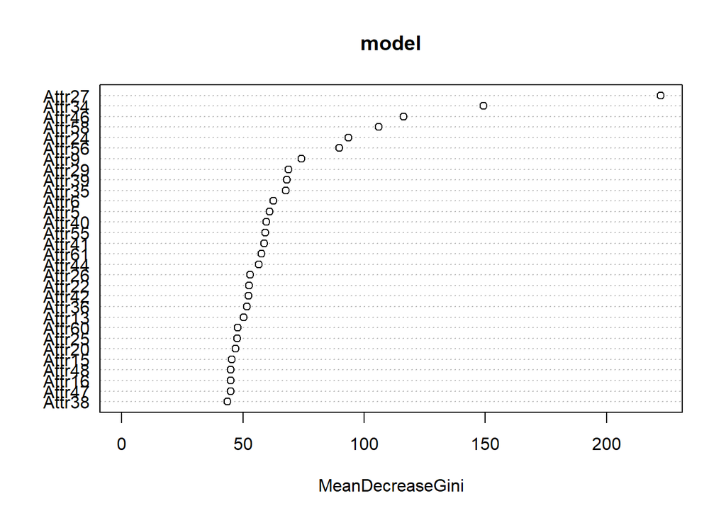

```r
varImpPlot(model)
```

# Select top 6 based on the importance

```r
imp_attr = as.character(rf_imp_attr$Attributes[1:6])
imp_attr
```

```
## [1] "Attr27" "Attr34" "Attr46" "Attr58" "Attr24" "Attr56"
```

Select important attributes from actual data and perform iterations

```r
imp_data = data[imp_attr]
imp_data_full <- imp_data
imp_data_full$target <- data$target
str(imp_data_full)
```

```
## 'data.frame':    36553 obs. of  7 variables:
##  $ Attr27: num  11.554 0.271 249.3 0.435 3.371 ...
##  $ Attr34: num  4.598 1.95 3.568 0.098 2.878 ...
##  $ Attr46: num  1.213 1.192 6.577 0.359 0.889 ...
##  $ Attr58: num  0.926 0.793 0.807 1.015 0.939 ...
##  $ Attr24: num  0.1676 0.0578 0.2354 -0.6893 0.2086 ...
##  $ Attr56: num  0.0787 0.2697 0.1599 -0.0153 0.1102 ...
##  $ target: Factor w/ 2 levels "0","1": 1 1 1 1 1 1 1 1 1 1 ...
```

# Perform outlier analysis - Box plot

First Feature - original Attr27

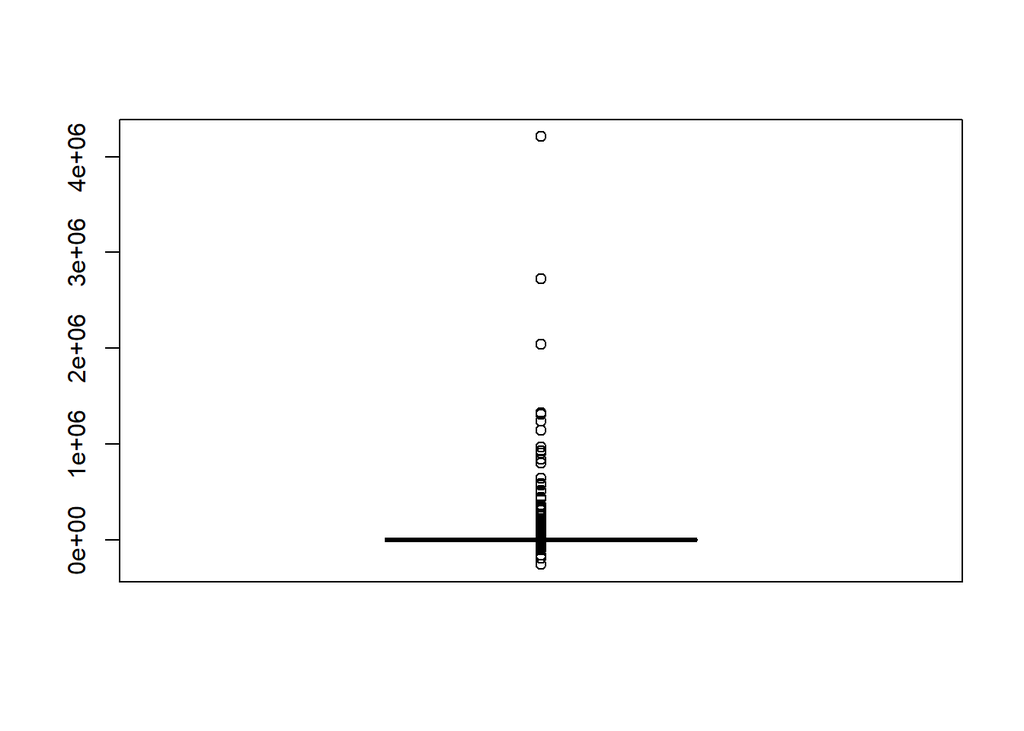

```
##           [,1]
## [1,] -7.663000
## [2,]  0.042639
## [3,]  1.090050
## [4,]  5.180500
## [5,] 12.887000
```

```r
boxplot(imp_data_full$Attr27)$stats
```

First feature - outlied Attr27

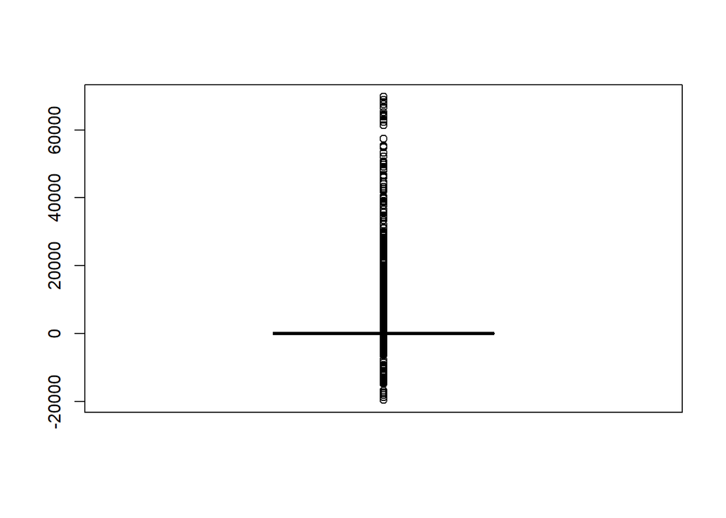

```
##          [,1]
## [1,] -7.53510
## [2,]  0.04179
## [3,]  1.08300
## [4,]  5.10670
## [5,] 12.70400
```

```r
imp_data_full$Attr27 = ifelse(imp_data_full$Attr27 >= 70000, NA, imp_data_full$Attr27)
imp_data_full$Attr27 = ifelse(imp_data_full$Attr27 <= -20000, NA, imp_data_full$Attr27)
boxplot(imp_data_full$Attr27)$stats
```

Second Feature - original Attr34

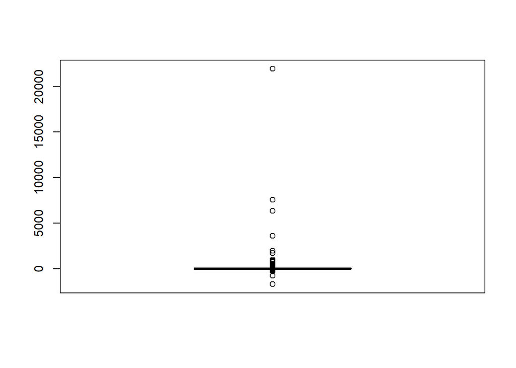

```
##         [,1]
## [1,] -6.0282
## [2,]  0.3115
## [3,]  1.9779
## [4,]  4.5613
## [5,] 10.9360
```

```r
boxplot(imp_data_full$Attr34)$stats
```

Second feature - outlied Attr34

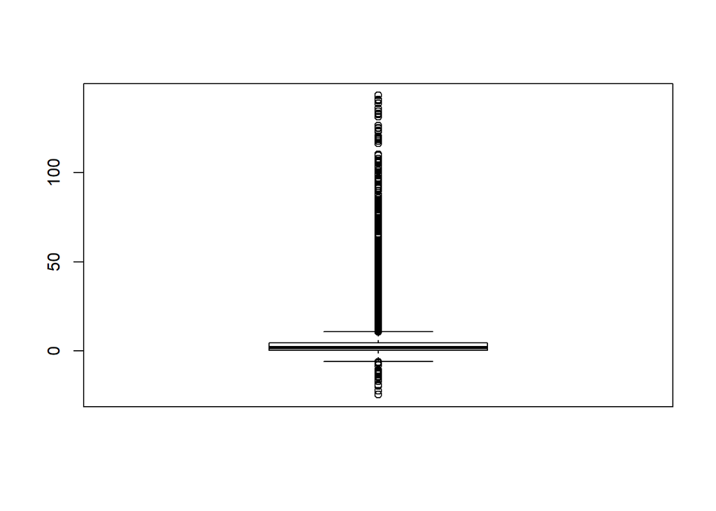

```
##          [,1]
## [1,] -6.02820
## [2,]  0.31107
## [3,]  1.97335
## [4,]  4.54350
## [5,] 10.89000
```

```r
imp_data_full$Attr34 = ifelse(imp_data_full$Attr34 >= 150, NA, imp_data_full$Attr34)
imp_data_full$Attr34 = ifelse(imp_data_full$Attr34 <= -25, NA, imp_data_full$Attr34)
boxplot(imp_data_full$Attr34)$stats
```

Third attribute - original Attr46

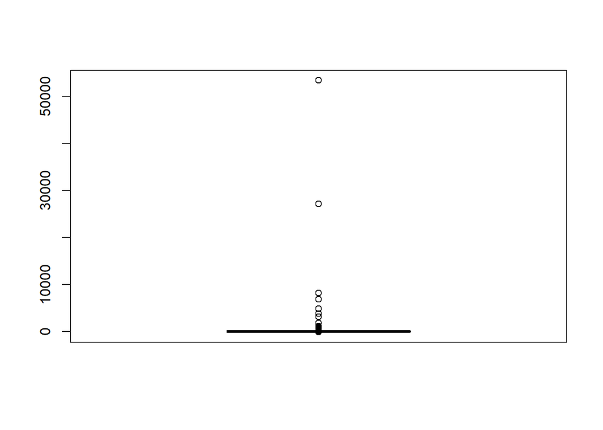

```
##          [,1]
## [1,] -0.17735
## [2,]  0.60823
## [3,]  1.02800
## [4,]  1.91540
## [5,]  3.87600
```

```r
boxplot(imp_data_full$Attr46)$stats
```

Third attribute - outlied Attr46

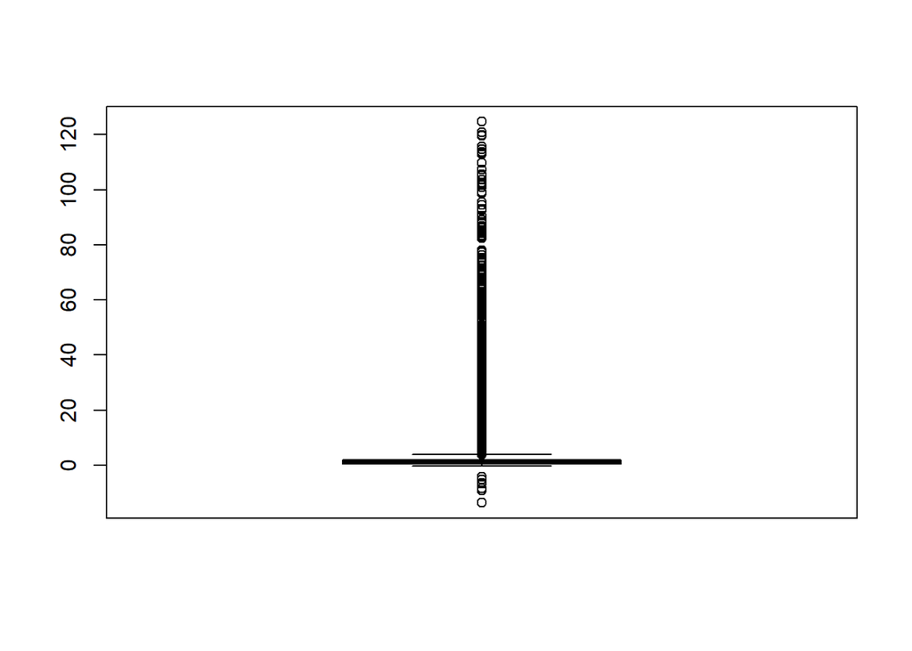

```
##          [,1]
## [1,] -0.17735
## [2,]  0.60711
## [3,]  1.02580
## [4,]  1.90500
## [5,]  3.85100
```

```r
imp_data_full$Attr46 = ifelse(imp_data_full$Attr46 >= 125, NA, imp_data_full$Attr46)
imp_data_full$Attr46 = ifelse(imp_data_full$Attr46 <= -50, NA, imp_data_full$Attr46)
boxplot(imp_data_full$Attr46)$stats
```

Fourth attribute - original Attr58

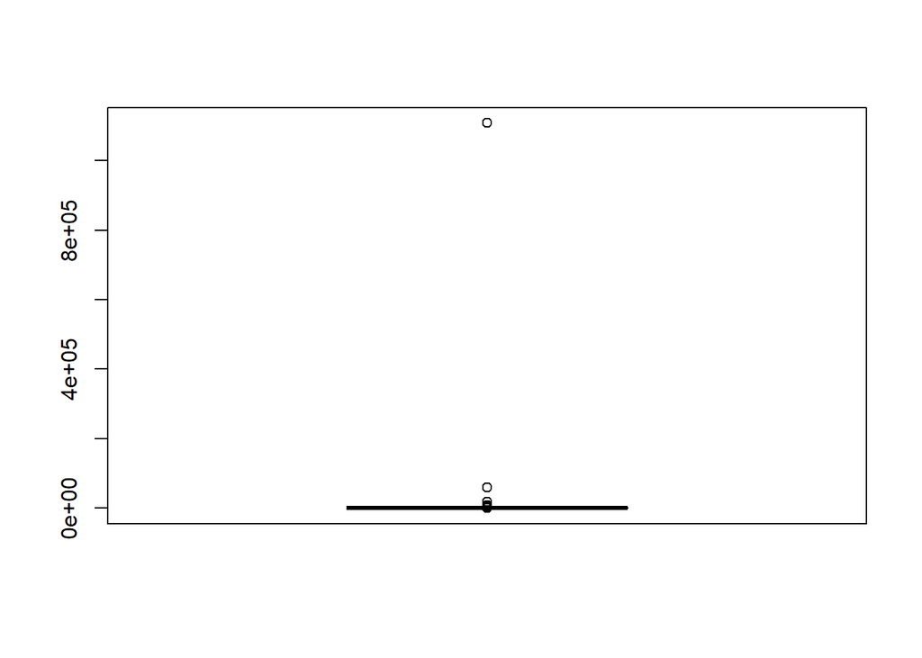

```
##         [,1]
## [1,] 0.69901
## [2,] 0.87519
## [3,] 0.95086
## [4,] 0.99271
## [5,] 1.16890
```

```r
boxplot(imp_data_full$Attr58)$stats
```

Fourth attribte - Outlied Attr58

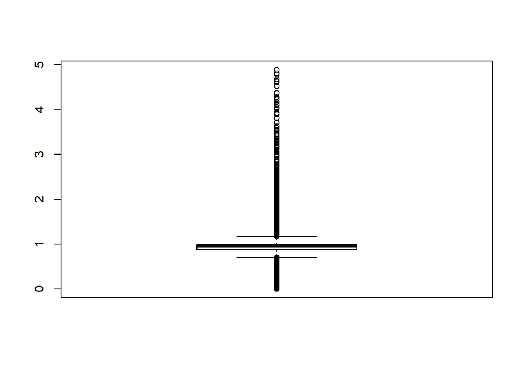

```
##          [,1]
## [1,] 0.699680
## [2,] 0.875350
## [3,] 0.950765
## [4,] 0.992480
## [5,] 1.168100
```

```r
imp_data_full$Attr58 = ifelse(imp_data_full$Attr58 >= 5, NA, imp_data_full$Attr58)
imp_data_full$Attr58 = ifelse(imp_data_full$Attr58 <= 0, NA, imp_data_full$Attr58)
boxplot(imp_data_full$Attr58)$stats
```

Fifth Attribute - original Attr56

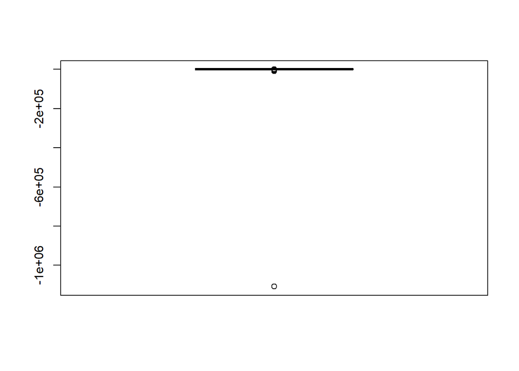

```
##            [,1]
## [1,] -0.1713100
## [2,]  0.0091442
## [3,]  0.0529365
## [4,]  0.1294550
## [5,]  0.3098900
```

```r
boxplot(imp_data_full$Attr56)$stats
```

Fifth Attribute - outlied Attr56

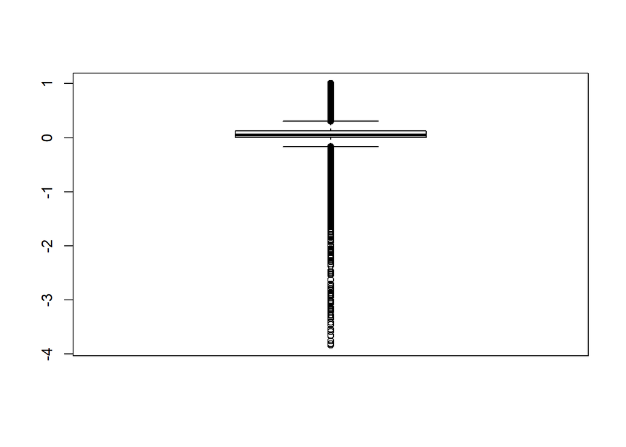

```
##            [,1]
## [1,] -0.1661400
## [2,]  0.0090615
## [3,]  0.0523790
## [4,]  0.1266900
## [5,]  0.3031300
```

```r
imp_data_full$Attr56 = ifelse(imp_data_full$Attr56 >= 1, NA, imp_data_full$Attr56)
imp_data_full$Attr56 = ifelse(imp_data_full$Attr56 <= -4, NA, imp_data_full$Attr56)
boxplot(imp_data_full$Attr56)$stats
```

Sixth Attribute - original Attr24

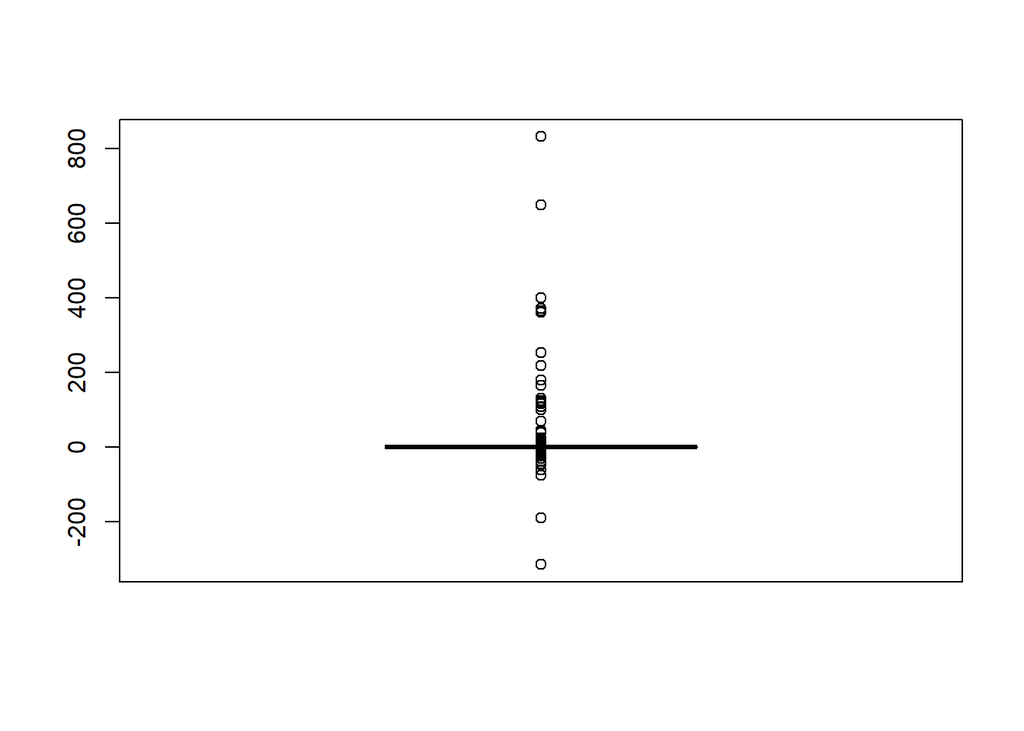

```
##            [,1]
## [1,] -0.4796700
## [2,]  0.0212365
## [3,]  0.1549600
## [4,]  0.3558700
## [5,]  0.8577600
```

```r
boxplot(imp_data_full$Attr24)$stats
```

Sixth attribute - outlied Attr24

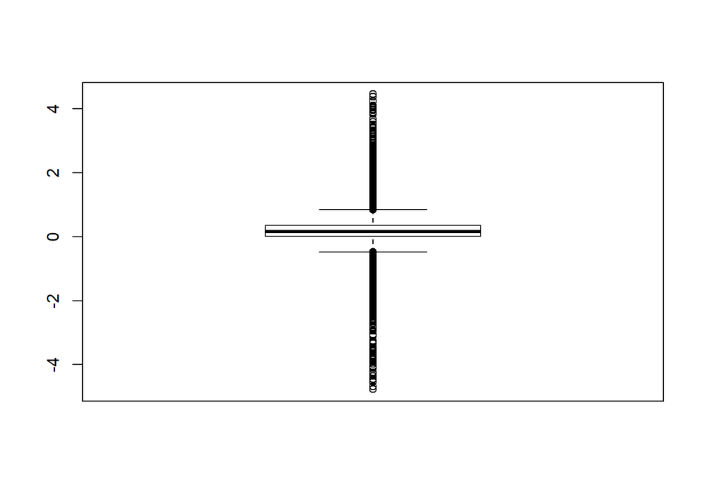

```r
imp_data_full$Attr24 = ifelse(imp_data_full$Attr24 >= 4.5, NA, imp_data_full$Attr24)
imp_data_full$Attr24 = ifelse(imp_data_full$Attr24 <= -5, NA, imp_data_full$Attr24)
boxplot(imp_data_full$Attr24)
```

# Missing value treatment - KNN imputation

Check missing values

```r
sum(is.na(imp_data_full))
```

```
## [1] 4437
```

Import libraries

```r
library(DMwR)
```

```r
imp_data_no_na = imp_data_full[rowSums(is.na(imp_data_full)) <= 3,]
str(imp_data_no_na)
```

```
## 'data.frame':    36518 obs. of  7 variables:
##  $ Attr27: num  11.554 0.271 249.3 0.435 3.371 ...
##  $ Attr34: num  4.598 1.95 3.568 0.098 2.878 ...
##  $ Attr46: num  1.213 1.192 6.577 0.359 0.889 ...
##  $ Attr58: num  0.926 0.793 0.807 1.015 0.939 ...
##  $ Attr24: num  0.1676 0.0578 0.2354 -0.6893 0.2086 ...
##  $ Attr56: num  0.0787 0.2697 0.1599 -0.0153 0.1102 ...
##  $ target: Factor w/ 2 levels "0","1": 1 1 1 1 1 1 1 1 1 1 ...
```

```r
imp_data_knn_imputed = knnImputation(imp_data_no_na, k = 7, scale = T, meth = "weighAvg", distData = NULL)
sum(is.na(imp_data_knn_imputed))
```

```
## [1] 0
```

Export to CSV

```r
write.csv(imp_data_knn_imputed, file="bankruptcy_imp_knn_imputed.csv")
```

# Train test split

Split imputed data

```r
set.seed(88)
trainrows = createDataPartition(y=imp_data_knn_imputed$target, p=0.8, list = FALSE)
train_split = imp_data_knn_imputed[trainrows,]
val_split = imp_data_knn_imputed[-trainrows,]
```

# Build Model - Logistic regression

Build model with glm for logistic regression

```r
log_reg_model = glm(formula = target~., data = train_split, family = binomial)
```

Predict the model from val_data

```r
log_reg_prediction = predict(log_reg_model, newdata=val_split[-7], type="response")
```

View predicted output

```r
View(round(log_reg_prediction,3))
```

# Logistic regression Model - apply cutoff based on distribution

Identify cutoff

```r
summary(imp_data_knn_imputed$target)
```

```
##     0     1
## 34755  1763
```

```r
cutoff = 1763/34755
cutoff
```

```
## [1] 0.05072651
```

Apply cutoff on prediction

```r
log_reg_output = ifelse(log_reg_prediction >= cutoff, 1, 0)
log_reg_output = as.factor(as.character(log_reg_output))
summary(log_reg_output)
```

```
##    0    1
## 5120 2183
```

# Metrics - Logistic regression without ROC

Import library

```r
library("MLmetrics")
```

Plot Confusion matrix

```r
confusionMatrix(log_reg_output, val_split$target)
```

```
## Confusion Matrix and Statistics
##
##           Reference
## Prediction    0    1
##          0 4978  142
##          1 1973  210
##
##                Accuracy : 0.7104
##                  95% CI : (0.6998, 0.7208)
##     No Information Rate : 0.9518
##     P-Value [Acc > NIR] : 1
##
##                   Kappa : 0.0902
##  Mcnemar's Test P-Value : <2e-16
##
##             Sensitivity : 0.7162
##             Specificity : 0.5966
##          Pos Pred Value : 0.9723
##          Neg Pred Value : 0.0962
##              Prevalence : 0.9518
##          Detection Rate : 0.6816
##    Detection Prevalence : 0.7011
##       Balanced Accuracy : 0.6564
##
##        'Positive' Class : 0
##
```

Calculate categorical metrics - Recall

```r
Recall(log_reg_output, val_split$target)
```

```
## [1] 0.9722656
```

Calculate categorical metrics - precision

```r
Precision(log_reg_output, val_split$target)
```

```
## [1] 0.7161559
```

Calculate categorical metrics - F1 score

```r
F1_Score(log_reg_output, val_split$target)
```

```
## [1] 0.8247867
```

# Logistic regression Model - apply cutoff based on ROC

Import library

```r
library("ROCR")
```

Calculate ROC

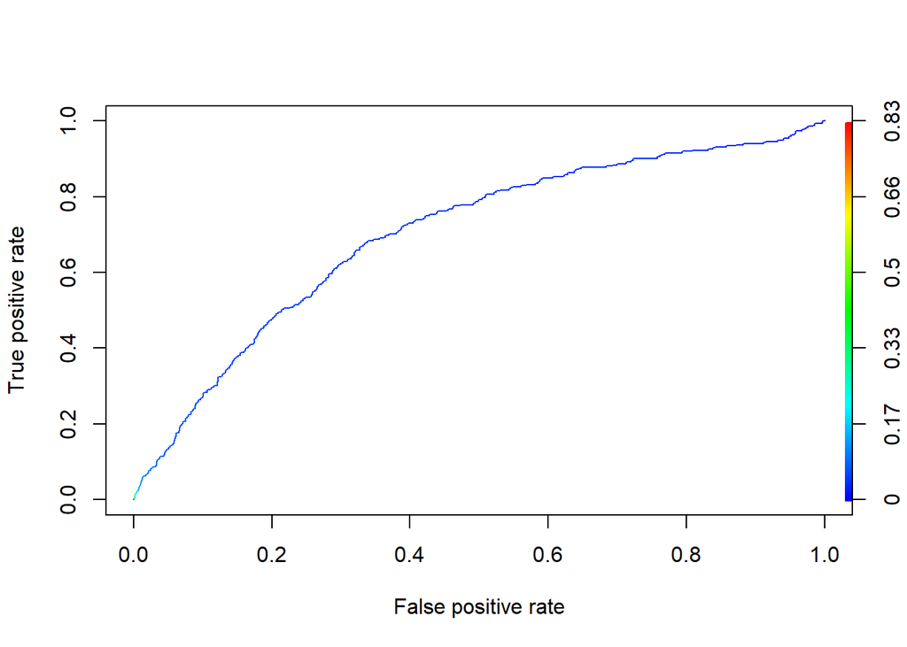

```r
rocr_pred = prediction(log_reg_prediction, val_split$target)
rocr_perf = performance(rocr_pred, "tpr", "fpr")
plot(rocr_perf, colorize = TRUE)
```

Get ROC cutoff value

```r
#install.packages("Epi")
library(Epi)
```

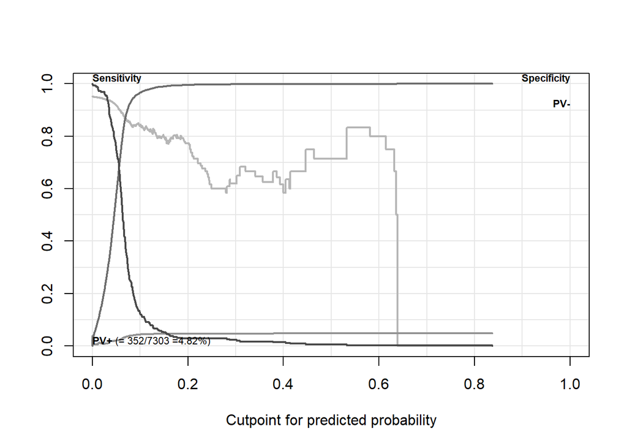

```r
rc <- ROC(form = target~., data = val_split, plot="sp")
```

```r
## optimal combination
opt <- which.max(rowSums(rc$res[, c("sens", "spec")]))
## optimal cut-off point
roc_cutoff = rc$res$lr.eta[opt]
roc_cutoff
```

```
## [1] 0.05503818
```

Plotting the ROC cutoff in graph

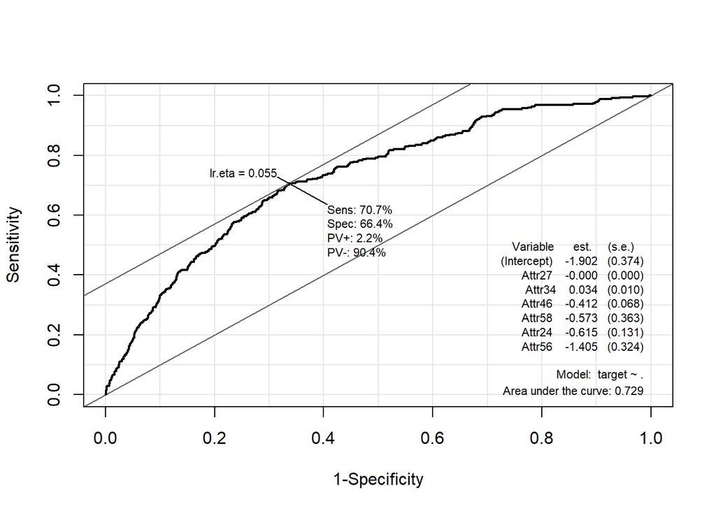

```r
ROC(form = target~., data = val_split, plot = "ROC", MX = TRUE)
```

Apply ROC cutoff on prediction

```r
log_reg_output = ifelse(log_reg_prediction >= roc_cutoff, 1, 0)
log_reg_output = as.factor(as.character(log_reg_output))
summary(log_reg_output)
```

```
##    0    1
## 5985 1318
```

# Metrics - Logistic regression with ROC

Import library

```r
library("MLmetrics")
```

Plot Confusion matrix

```r
confusionMatrix(log_reg_output, val_split$target)
```

```
## Confusion Matrix and Statistics
##
##           Reference
## Prediction    0    1
##          0 5777  208
##          1 1174  144
##
##                Accuracy : 0.8108
##                  95% CI : (0.8016, 0.8197)
##     No Information Rate : 0.9518
##     P-Value [Acc > NIR] : 1
##
##                   Kappa : 0.1043
##  Mcnemar's Test P-Value : <2e-16
##
##             Sensitivity : 0.8311
##             Specificity : 0.4091
##          Pos Pred Value : 0.9652
##          Neg Pred Value : 0.1093
##              Prevalence : 0.9518
##          Detection Rate : 0.7910
##    Detection Prevalence : 0.8195
##       Balanced Accuracy : 0.6201
##
##        'Positive' Class : 0
##
```

Calculate categorical metrics - Recall

```r
Recall(log_reg_output, val_split$target)
```

```
## [1] 0.9652464
```

Calculate categorical metrics - precision

```r
Precision(log_reg_output, val_split$target)
```

```
## [1] 0.8311034
```

Calculate categorical metrics - F1 score

```r
F1_Score(log_reg_output, val_split$target)
```

```
## [1] 0.8931664
```

# Build Model - KNN

Install libraries

```r
#install.packages("class")
library("class")
```

Perform KNN classification

```r
knn_class_prediction = knn(train = train_split[-7], test = val_split[-7], cl = train_split$target, k=7 )
```

# Metrics - KNN

Finding accuracy

```r
#install.packages("gmodels")
library("gmodels")
```

Using crosstable for confusion matrix

```r
CrossTable(x = val_split$target, y = knn_class_prediction, prop.chisq = FALSE)
```

```
##
##
##    Cell Contents
## |-------------------------|
## |                       N |
## |           N / Row Total |
## |           N / Col Total |
## |         N / Table Total |
## |-------------------------|
##
##
## Total Observations in Table:  7303
##
##
##                  | knn_class_prediction
## val_split$target |         0 |         1 | Row Total |
## -----------------|-----------|-----------|-----------|
##                0 |      6911 |        40 |      6951 |
##                  |     0.994 |     0.006 |     0.952 |
##                  |     0.961 |     0.367 |           |
##                  |     0.946 |     0.005 |           |
## -----------------|-----------|-----------|-----------|
##                1 |       283 |        69 |       352 |
##                  |     0.804 |     0.196 |     0.048 |
##                  |     0.039 |     0.633 |           |
##                  |     0.039 |     0.009 |           |
## -----------------|-----------|-----------|-----------|
##     Column Total |      7194 |       109 |      7303 |
##                  |     0.985 |     0.015 |           |
## -----------------|-----------|-----------|-----------|
##
##
```

Calculate Accuracy

```r
(6911+69)/7303
```

```
## [1] 0.9557716
```

Install MLmetrics

```r
library("MLmetrics")
```

Calculate categorical metrics - Recall

```r
Recall(y_true = val_split$target, y_pred = knn_class_prediction)
```

```
## [1] 0.9942454
```

Calculate categorical metrics - precision

```r
Precision(y_true = val_split$target, y_pred = knn_class_prediction)
```

```
## [1] 0.9606617
```

Calculate categorical metrics - F1 score

```r
F1_Score(y_true = val_split$target, y_pred = knn_class_prediction)
```

```
## [1] 0.9771651
```

# Build Model - Random Forest

Build model

Load Random forest library

```r
library(caret)
library(randomForest)
```

```r
rf_model = randomForest(target~., data=train_split, keep.forest=TRUE, do.trace=TRUE, ntrees=50)
```

```
## ntree      OOB      1      2
##     1:   6.60%  3.96% 61.49%
##     2:   6.76%  3.91% 65.01%
##     3:   6.53%  3.64% 65.75%
##     4:   6.34%  3.29% 67.49%
##     5:   5.97%  2.84% 68.67%
##     6:   5.87%  2.64% 69.89%
##     7:   5.68%  2.41% 70.35%
##     8:   5.43%  2.14% 70.12%
##     9:   5.32%  2.01% 70.33%
##    10:   5.05%  1.75% 69.93%
##    11:   4.87%  1.54% 70.32%
##    12:   4.73%  1.39% 70.48%
##    13:   4.66%  1.27% 71.31%
##    14:   4.64%  1.20% 72.15%
```

[output cut: 486 more lines]

Predict validation data using random forest

```r
rf_prediction = predict(rf_model, val_split[-7], type="response", norm.votes=TRUE)
```

# Metrics - Random Forest

Confusion Matrix

```r
confusionMatrix(data = rf_prediction, reference = val_split$target,positive = "1")
```

```
## Confusion Matrix and Statistics
##
##           Reference
## Prediction    0    1
##          0 6933  265
##          1   18   87
##
##                Accuracy : 0.9612
##                  95% CI : (0.9566, 0.9656)
##     No Information Rate : 0.9518
##     P-Value [Acc > NIR] : 5.677e-05
##
##                   Kappa : 0.3667
##  Mcnemar's Test P-Value : < 2.2e-16
##
##             Sensitivity : 0.24716
##             Specificity : 0.99741
##          Pos Pred Value : 0.82857
##          Neg Pred Value : 0.96318
##              Prevalence : 0.04820
##          Detection Rate : 0.01191
##    Detection Prevalence : 0.01438
##       Balanced Accuracy : 0.62228
##
##        'Positive' Class : 1
##
```

Recall - Rf

```r
Recall(y_true = val_split$target, y_pred = rf_prediction)
```

```
## [1] 0.9974104
```

Precision - rf

```r
Precision(y_true = val_split$target, y_pred = rf_prediction)
```

```
## [1] 0.9631842
```

Sensitivity - Rf

```r
Sensitivity(y_true = val_split$target, y_pred = rf_prediction)
```

```
## [1] 0.9974104
```

Specificity - Rf

```r
Specificity(y_true = val_split$target, y_pred = rf_prediction)
```

```
## [1] 0.2471591
```

F1 Score - Rf

```r
F1_Score(y_true = val_split$target, y_pred = rf_prediction)
```

```
## [1] 0.9799986
```

# Build Model - CART

Install libraries

```r
#install.packages("rpart")
library(rpart)
```

Build CART model

```r
cart_model = rpart(train_split$target~.,data = train_split)
summary(cart_model)
```

```
## Call:
## rpart(formula = train_split$target ~ ., data = train_split)
##   n= 29215
##
##           CP nsplit rel error    xerror       xstd
## 1 0.01169383      0 1.0000000 1.0000000 0.02597091
## 2 0.01027640      4 0.9532247 0.9369242 0.02517870
## 3 0.01000000      7 0.9213324 0.9149539 0.02489556
##
## Variable importance
## Attr27 Attr46 Attr34 Attr58 Attr56 Attr24
##     48     12     12     11      9      7
##
## Node number 1: 29215 observations,    complexity param=0.01169383
##   predicted class=0  expected loss=0.04829711  P(node) =1
##     class counts: 27804  1411
##    probabilities: 0.952 0.048
##   left son=2 (26286 obs) right son=3 (2929 obs)
##   Primary splits:
##       Attr27 < -1.32335    to the right, improve=108.74530, (0 missing)
##       Attr24 < 0.0528745   to the right, improve= 70.25247, (0 missing)
##       Attr46 < 0.46571     to the right, improve= 68.25878, (0 missing)
##       Attr56 < -0.0669505  to the right, improve= 42.24622, (0 missing)
##       Attr58 < 1.06105     to the left,  improve= 31.91355, (0 missing)
##   Surrogate splits:
##       Attr58 < 1.08055     to the left,  agree=0.930, adj=0.305, (0 split)
##       Attr56 < -0.088551   to the right, agree=0.927, adj=0.273, (0 split)
##       Attr24 < -0.415285   to the right, agree=0.908, adj=0.086, (0 split)
##       Attr34 < -0.595915   to the right, agree=0.902, adj=0.026, (0 split)
##
## Node number 2: 26286 observations,    complexity param=0.0102764
##   predicted class=0  expected loss=0.03389637  P(node) =0.8997433
##     class counts: 25395   891
##    probabilities: 0.966 0.034
##   left son=4 (21734 obs) right son=5 (4552 obs)
##   Primary splits:
##       Attr46 < 0.52475     to the right, improve=22.267120, (0 missing)
##       Attr24 < 0.0605785   to the right, improve=20.475500, (0 missing)
##       Attr27 < 0.944505    to the left,  improve=11.046240, (0 missing)
##       Attr56 < 0.03623476  to the right, improve= 4.174310, (0 missing)
```

[output cut: 114 more lines]

```
##
## Node number 23: 47 observations
##   predicted class=1  expected loss=0.0212766  P(node) =0.001608763
##     class counts:     1    46
##    probabilities: 0.021 0.979
##
## Node number 30: 162 observations
##   predicted class=0  expected loss=0.1419753  P(node) =0.005545097
##     class counts:   139    23
##    probabilities: 0.858 0.142
##
## Node number 31: 136 observations
##   predicted class=1  expected loss=0.2573529  P(node) =0.004655143
##     class counts:    35   101
##    probabilities: 0.257 0.743
```

Predict using CART

```r
cart_prediction = predict(cart_model, val_split[-7], type = "class")
```

# Metrics - CART

Confusion Matrix

```r
confusionMatrix(data = cart_prediction, reference = val_split$target,positive = "1")
```

```
## Confusion Matrix and Statistics
##
##           Reference
## Prediction    0    1
##          0 6940  324
##          1   11   28
##
##                Accuracy : 0.9541
##                  95% CI : (0.9491, 0.9588)
##     No Information Rate : 0.9518
##     P-Value [Acc > NIR] : 0.1841
##
##                   Kappa : 0.1349
##  Mcnemar's Test P-Value : <2e-16
##
##             Sensitivity : 0.079545
##             Specificity : 0.998417
##          Pos Pred Value : 0.717949
##          Neg Pred Value : 0.955396
##              Prevalence : 0.048199
##          Detection Rate : 0.003834
##    Detection Prevalence : 0.005340
##       Balanced Accuracy : 0.538981
##
##        'Positive' Class : 1
##
```

Calculate categorical metrics - Recall

```r
Recall(y_true = val_split$target, y_pred = cart_prediction)
```

```
## [1] 0.9984175
```

Calculate categorical metrics - precision

```r
Precision(y_true = val_split$target, y_pred = cart_prediction)
```

```
## [1] 0.9553965
```

Calculate categorical metrics - sensitivity

```r
Sensitivity(y_true = val_split$target, y_pred = cart_prediction)
```

```
## [1] 0.9984175
```

Calculate categorical metrics - specificity

```r
Specificity(y_true = val_split$target, y_pred = cart_prediction)
```

```
## [1] 0.07954545
```

Calculate categorical metrics - F1 Score

```r
F1_Score(y_true = val_split$target, y_pred = cart_prediction)
```

```
## [1] 0.9764333
```

# Build Model - C5.0

Install packages

```r
#install.packages("C50")
library("C50")
```

Build model C5.0

```r
c50_model = C5.0(x = train_split[-7], y = train_split$target)
summary(c50_model)
```

```
##
## Call:
## C5.0.default(x = train_split[-7], y = train_split$target)
##
##
## C5.0 [Release 2.07 GPL Edition]      Wed Dec 26 09:46:56 2018
## -------------------------------
##
## Class specified by attribute `outcome'
##
## Read 29215 cases (7 attributes) from undefined.data
##
## Decision tree:
##
## Attr27 <= -1.3239:
## :...Attr34 > 0.15412:
## :   :...Attr56 <= 0.011009: 0 (2178/271)
## :   :   Attr56 > 0.011009:
## :   :   :...Attr46 > 0.44105: 0 (150/39)
## :   :       Attr46 <= 0.44105:
## :   :       :...Attr24 <= -0.62885: 0 (12/1)
## :   :           Attr24 > -0.62885: 1 (62/26)
## :   Attr34 <= 0.15412:
## :   :...Attr27 > -4.1066:
## :       :...Attr58 > 1.1275: 0 (203/1)
## :       :   Attr58 <= 1.1275:
## :       :   :...Attr27 <= -2.393:
## :       :       :...Attr56 <= 0.011989: 1 (21/1)
## :       :       :   Attr56 > 0.011989: 0 (7/1)
## :       :       Attr27 > -2.393:
## :       :       :...Attr34 <= -0.12183: 0 (35)
## :       :           Attr34 > -0.12183:
## :       :           :...Attr34 <= 0.068698: 0 (12/4)
## :       :               Attr34 > 0.068698: 1 (5)
## :       Attr27 <= -4.1066:
## :       :...Attr58 > 1.449: 0 (61/11)
## :           Attr58 <= 1.449:
## :           :...Attr56 > 0.017109: 0 (17/1)
## :               Attr56 <= 0.017109:
## :               :...Attr34 <= -1.7385: 0 (9/2)
```

[output cut: 93 more lines]

```
##   27754    50    (a): class 0
##    1015   396    (b): class 1
##
##
##  Attribute usage:
##
##  100.00% Attr27
##   90.80% Attr46
##   74.44% Attr24
##   59.03% Attr34
##    9.76% Attr56
##    2.87% Attr58
##
##
## Time: 0.6 secs
```

Predict model on validation data

```r
c50_prediction = predict(c50_model, newdata=val_split[-7])
```

# Metrics - C5.0

Confusion Matrix

```r
confusionMatrix(data = c50_prediction, reference = val_split$target, positive = "1")
```

```
## Confusion Matrix and Statistics
##
##           Reference
## Prediction    0    1
##          0 6922  272
##          1   29   80
##
##                Accuracy : 0.9588
##                  95% CI : (0.954, 0.9632)
##     No Information Rate : 0.9518
##     P-Value [Acc > NIR] : 0.002422
##
##                   Kappa : 0.3318
##  Mcnemar's Test P-Value : < 2.2e-16
##
##             Sensitivity : 0.22727
##             Specificity : 0.99583
##          Pos Pred Value : 0.73394
##          Neg Pred Value : 0.96219
##              Prevalence : 0.04820
##          Detection Rate : 0.01095
##    Detection Prevalence : 0.01493
##       Balanced Accuracy : 0.61155
##
##        'Positive' Class : 1
##
```

Calculate categorical metrics - Recall

```r
Recall(y_true = val_split$target, y_pred = c50_prediction)
```

```
## [1] 0.9958279
```

Calculate categorical metrics - precision

```r
Precision(y_true = val_split$target, y_pred = c50_prediction)
```

```
## [1] 0.9621907
```

Calculate categorical metrics - sensitivity

```r
Sensitivity(y_true = val_split$target, y_pred = c50_prediction)
```

```
## [1] 0.9958279
```

Calculate categorical metrics - specificity

```r
Specificity(y_true = val_split$target, y_pred = c50_prediction)
```

```
## [1] 0.2272727
```

Calculate categorical metrics - F1 Score

```r
F1_Score(y_true = val_split$target, y_pred = c50_prediction)
```

```
## [1] 0.9787204
```

# Build Model - Naive Bayes

Install Libraries

```r
#install.packages("naivebayes")
library("naivebayes")
```

Build model

```r
naive_model = naive_bayes(x = train_split[-7], y = train_split$target)
summary(naive_model)
```

```
##           Length Class  Mode
## data      2      -none- list
## levels    2      -none- character
## laplace   1      -none- numeric
## tables    6      -none- list
## prior     2      table  numeric
## usekernel 1      -none- logical
## call      3      -none- call
```

Predict model

```r
naive_prediction = predict(naive_model, newdata = val_split[-7])
summary(naive_prediction)
```

```
##    0    1
## 6921  382
```

# Metrics - Naive Bayes

Confusion Matrix

```r
confusionMatrix(data = naive_prediction, reference = val_split$target, positive = "1")
```

```
## Confusion Matrix and Statistics
##
##           Reference
## Prediction    0    1
##          0 6601  320
##          1  350   32
##
##                Accuracy : 0.9083
##                  95% CI : (0.9014, 0.9148)
##     No Information Rate : 0.9518
##     P-Value [Acc > NIR] : 1.0000
##
##                   Kappa : 0.039
##  Mcnemar's Test P-Value : 0.2626
##
##             Sensitivity : 0.090909
##             Specificity : 0.949648
##          Pos Pred Value : 0.083770
##          Neg Pred Value : 0.953764
##              Prevalence : 0.048199
##          Detection Rate : 0.004382
##    Detection Prevalence : 0.052307
##       Balanced Accuracy : 0.520278
##
##        'Positive' Class : 1
##
```

Calculate categorical metrics - Recall

```r
Recall(y_true = val_split$target, y_pred = naive_prediction)
```

```
## [1] 0.9496475
```

Calculate categorical metrics - precision

```r
Precision(y_true = val_split$target, y_pred = naive_prediction)
```

```
## [1] 0.9537639
```

Calculate categorical metrics - sensitivity

```r
Sensitivity(y_true = val_split$target, y_pred = naive_prediction)
```

```
## [1] 0.9496475
```

Calculate categorical metrics - specificity

```r
Specificity(y_true = val_split$target, y_pred = naive_prediction)
```

```
## [1] 0.09090909
```

Calculate categorical metrics - F1 Score

```r
F1_Score(y_true = val_split$target, y_pred = naive_prediction)
```

```
## [1] 0.9517013
```